# BayWheel Bike Data Visualziation

Welcome to Baywheel's bike visualization! Here we have a dataset from Lyft showcasing the useage of shared bike in the Bay area in 2018. We want to figure out the basic demography of the users as well as its relationship with trip duration. In addition, we want to derive some time-based visualizations illustrating when people like to bike based on time in a day, days in a week, and months in a year. Lastly, we want to explore where exactly people like to bike in the Bay - thus we've dived deep and done some hardcore work in transforming original dataset into geojson data, setting up the schema grouped by zip, and finally visualizing the trip frequencies on a Bay area map.

## Data Extraction

## Data Exploration/Cleaning

# Data Viualization

### Q1: When does people usually like to bike?

First of all, we'd like to figure out when people like to bike around in different metrics. That'd be useful to build a pattern that would help better distributing the bikes based on demand of different time periods.

We'll start off by weekday/weekend.

### Breakdown of Rides by Weekday/Weekend

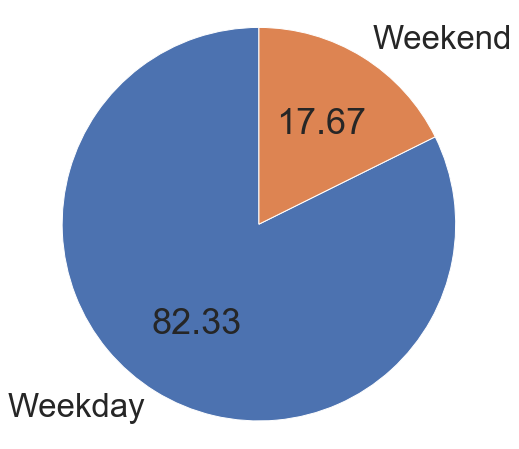

```python
plt.figure(figsize=[8,8])
timeofweek_counts = dfc.timeofweek.value_counts()
plt.pie(timeofweek_counts, labels=timeofweek_counts.index, startangle=90, autopct=lambda val: val.round(2));
plt.axis('square');
```

Apparently, the majority of the bikes ride on the weekday. Do they bike to commute or just for fun? Maybe taking a look at the day period (morning/afternoon/evening) distribution would help us determine.

### Ride Distribution in Day Periods

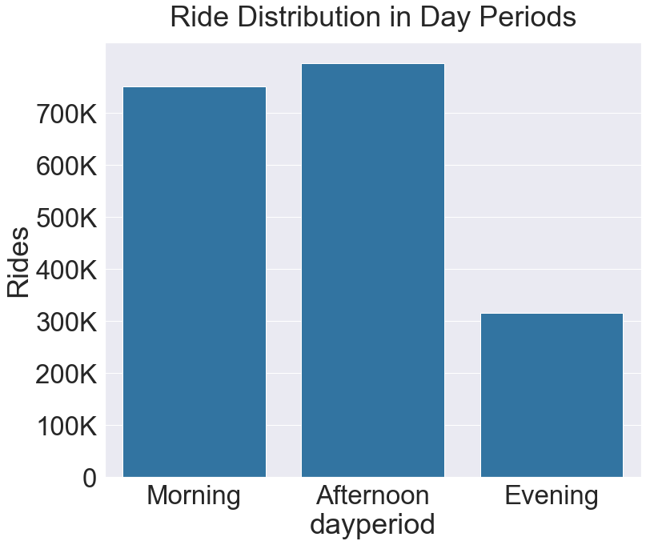

```python
plt.figure(figsize = [12, 10])
dayperiod_order = ['Morning', 'Afternoon', 'Evening']
sb.countplot(data=dfc, x="dayperiod", color=base_color, order=dayperiod_order);
y_ticks_props = np.arange(0, dfc.groupby('dayperiod').bike_id.count().max()+1, 100000);
y_ticks_display = [ format_ride_count(numRide) for numRide in y_ticks_props]
plt.yticks(y_ticks_props, y_ticks_display);
plt.ylabel('Rides');
plt.title('Ride Distribution in Day Periods', pad=20);
```

Maybe they do bike for commuting as the majority of rides takes place during morning and afternoon. To confirm, let's dive deep and take a look at the hourly distribution.

### Hourly Ride Distribution

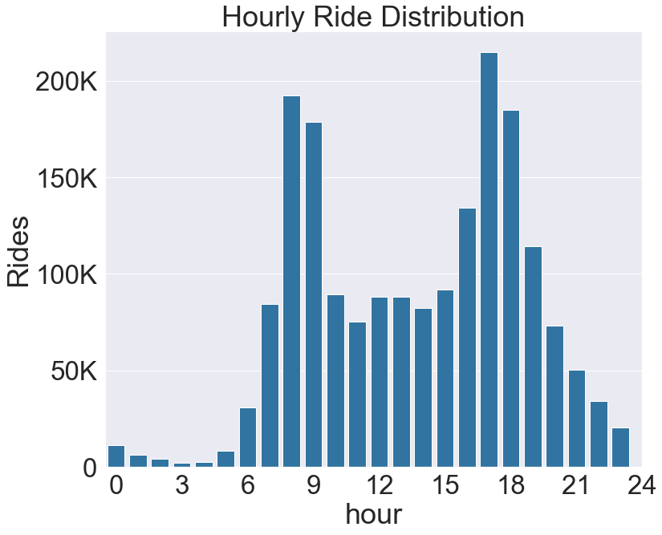

```python
plt.figure(figsize = [12, 10])
hour_order = np.arange(0, 24, 1)
sb.countplot(data=dfc, x="hour", color=base_color, order=hour_order);
y_ticks_props = np.arange(0, dfc.groupby('hour').bike_id.count().max()+1, 50000);
y_ticks_display = [ format_ride_count(numRide) for numRide in y_ticks_props]
plt.xticks(np.arange(0, 24+1, 3), np.arange(0, 24+1, 3));
plt.yticks(y_ticks_props, y_ticks_display);
plt.ylabel('Rides');
plt.title('Hourly Ride Distribution');
```

It might actually be the case. As we can see from the bar chart, the peak traffic is around 7-9 (morning commute) and 16-18 (afternoon commute(). There's a consistent traffic in between the two peaks, and after 7pm traffic starts to go down.

### Monthly Ride Distribution

Now let's examine the data set from the month's perspective. In which month do people bike the most? Let's find out by building a barplot based on month.

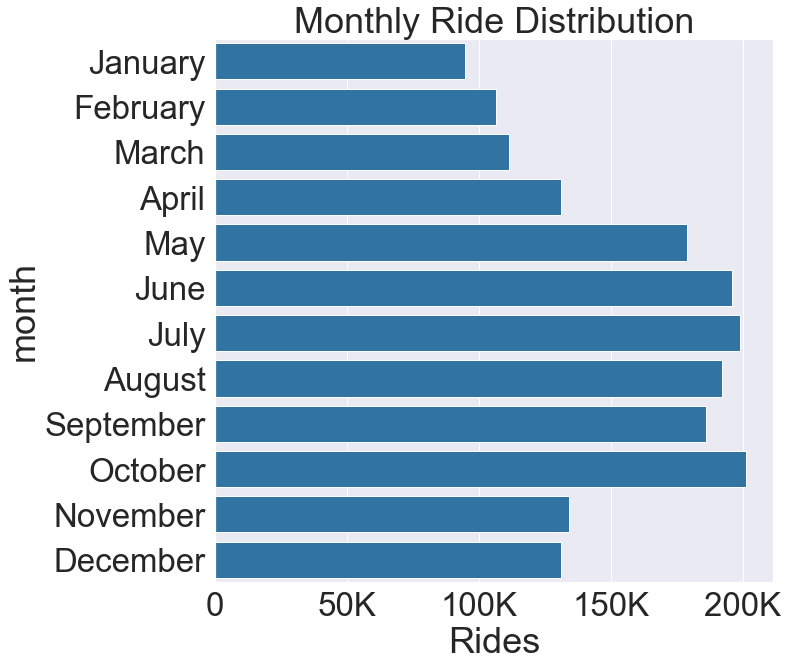

```python
plt.figure(figsize = [10, 10])
month_order = ['January', 'February', 'March', 'April', 'May', 'June', 'July', 'August', 'September', 'October', 'November', 'December']
sb.countplot(data=dfc, y="month", color=base_color, order=month_order);
plt.xlabel('Rides');
plt.ylabel('Month');
x_ticks_props = np.arange(0, dfc.month.value_counts().max()+1, 50000);
x_ticks_display = [ format_ride_count(numRide) for numRide in x_ticks_props]
plt.xticks(x_ticks_props, x_ticks_display);
plt.title('Monthly Ride Distribution');
```

To better display the month labels, I've set the barplot to be horizontal. Here we could see that apparently people like to bike in summer and fall - especially in the months from May to October. It makes sense because the weather during that those seasons are more ideal for biking.

Now that we've examined the data from a chronological standpoint, let's switch gears and try to play around with demographic attributes. Nos vamos!

### Q2: Who likes to ride a bike the most?

We would like to start off with some usual univariate analysis. Let's take a look at the age group - do older people prefer to bike than the younger people?

### Ride Distribution among Age Groups

```
['0', '250K', '500K', '750K', '1,000K']
```

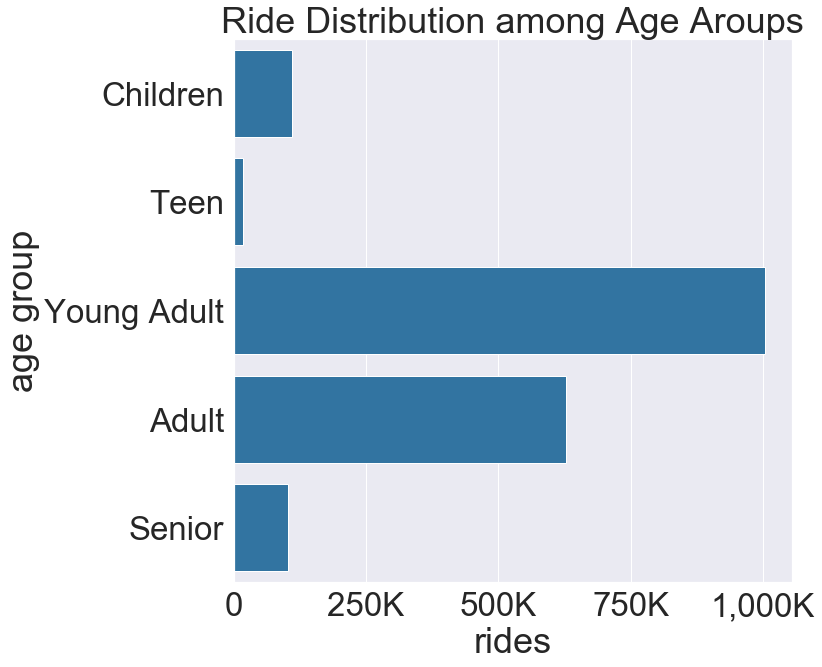

```python
plt.figure(figsize = [10, 10])
age_order = ['Children', 'Teen', 'Young Adult', 'Adult', 'Senior']
sb.countplot(data=dfc, y="member_age_group", color=base_color, order=age_order);
x_ticks_props_age = np.arange(0, dfc['member_age_group'].value_counts().max()+1, 250000);
x_ticks_display_age = [ format_ride_count(numRide) for numRide in x_ticks_props_age]
plt.xticks(x_ticks_props_age, x_ticks_display_age);
plt.xlabel('Rides');
plt.ylabel('Age Group');
plt.title('Ride Distribution among Age Aroups');
x_ticks_display_age
```

This categorization might be a bit general. What if we break down the age by range of 10?

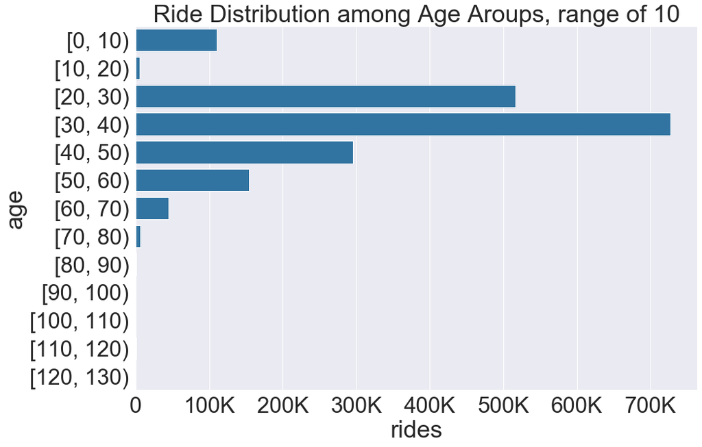

```python
# todo: convert xtick label to "start_age - end_age", e.g., 10-20 instead of [10, 20]
plt.figure(figsize=[15,10])
sb.countplot(data=dfc, y="age_by_10", color=base_color);
x_ticks_props = np.arange(0, dfc['age_by_10'].value_counts().max()+1, 100000);
x_ticks_display = [ format_ride_count(numRide) for numRide in x_ticks_props]
plt.xticks(x_ticks_props, x_ticks_display);
plt.xlabel('Rides');
plt.ylabel('Age');
plt.title('Ride Distribution among Age Aroups, range of 10');
```

As we could see from above, most riders fall into the range of 20-50, which makes sense. Let's now try a bivariate visualization. What's the relationship between trip duration and age group? For the sake of simplicity, we'll use the duration in minute as our metric.

### Trip Duration Summary for Different Age Groups - Part I

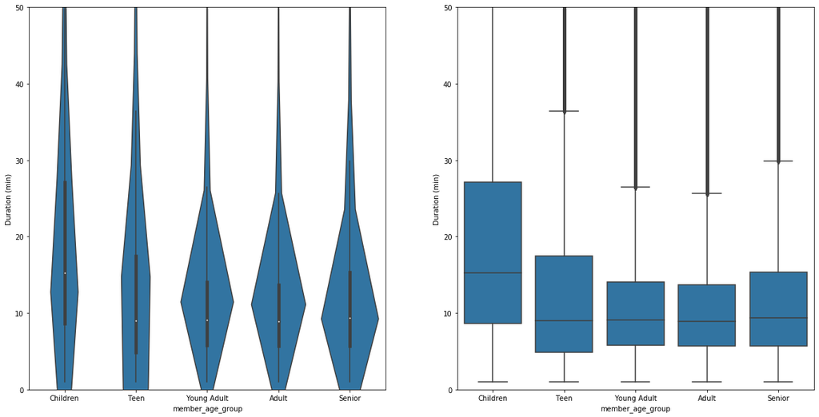

```python
plt.figure(figsize = [20, 10])
plt.subplot(1, 2, 1)
ax1 = sb.violinplot(data=dfc, x="member_age_group", y="duration_min", color=base_color, order=age_order)
plt.ylim(0, 50);
plt.ylabel("Duration (min)")

plt.subplot(1, 2, 2)
ax2 = sb.boxplot(data=dfc, x="member_age_group", y="duration_min", color=base_color, order=age_order)
plt.ylabel("Duration (min)");
plt.ylim(0, 50);
```

As we could see, surprisingly children seem to have the longest duration. However as we recall for a lot the records that don't have a birth year, we simply assign their age to be 0. Let's clean it up and run the plots again.

### Trip Duration Summary for Different Age Groups - Part II

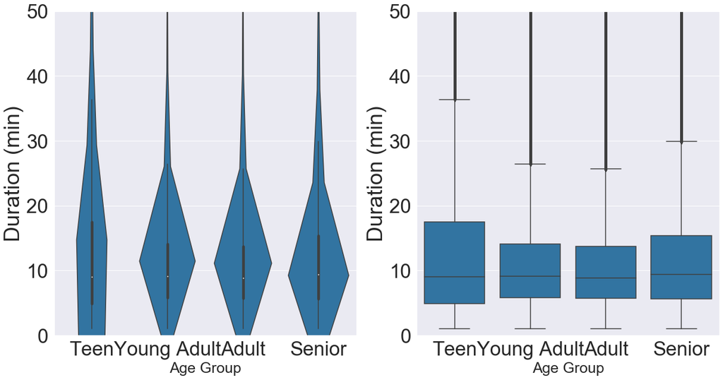

```python
plt.figure(figsize = [20, 10])
plt.subplot(1, 2, 1)
ax1 = sb.violinplot(data=dfc_by_age, x="member_age_group", y="duration_min", color=base_color, order=age_order[1:])
plt.ylim(0, 50);
plt.xlabel("Age Group", fontsize='xx-small');
plt.ylabel("Duration (min)")

plt.subplot(1, 2, 2)
ax2 = sb.boxplot(data=dfc_by_age, x="member_age_group", y="duration_min", color=base_color, order=age_order[1:])
plt.xlabel("Age Group", fontsize='xx-small');
plt.ylabel("Duration (min)");
plt.ylim(0, 50);
```

Hmm, that makes a difference. Now the children group is completely gone - and teens take the lead among all age groups. Surprisingly, the seniors come nextm trailing by a small margin.

Next, let's examine the distribution between user types (subscriber/customer)

### Breakdown of Rides in User Types

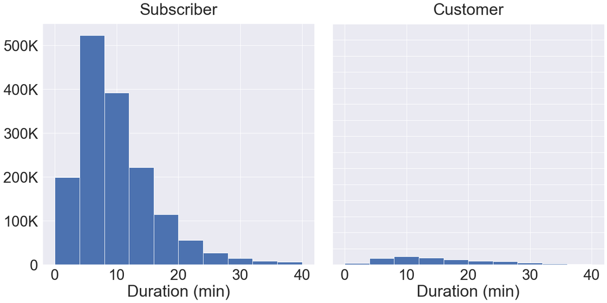

```python
g = sb.FacetGrid(data=dfc, col="user_type");
sb.set(font_scale = 3)
g.fig.set_size_inches(20,10)
g.map(plt.hist, "duration_min", range=[0,40]);
g.set_titles('{col_name}', pad=20);
for ax in g.axes.flatten():
    ax.set_xlabel('Duration (min)');
y_ticks_props = np.arange(0, dfc.user_type.value_counts().max()+1, 100000);
y_ticks_display = [ format_ride_count(numRide) for numRide in y_ticks_props]
plt.yticks(y_ticks_props, y_ticks_display);
```

As we could see, the majority of users are subscribers while just a small portion of users are occasional customers. For both groups, most data points fall into the range of 0-20 minutes. Nevertheless, the spread of subscribers is much greater than the customers, which is comparatively more even-out. For subscribers, the bulk of the data points of subscribers fall in 5-15 minutes.

### Q3: How about taking both time and age into consideration in terms of the trip duration?

Let's try to draw a clustered bar plot to illustrate the impacts of day period (morning/afternoon/evening) and age on average trip duration.

### Relationship between Trip Duration and Daytime, Age

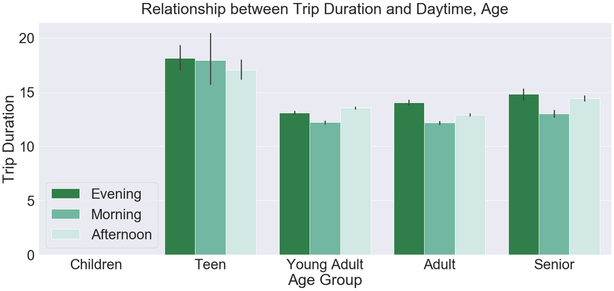

```python
plt.figure(figsize = [24, 10])
ax = sb.barplot(data=dfc_by_age, x="member_age_group", y="duration_min", hue="dayperiod", order=age_order, palette="BuGn_r");
ax.legend(loc=3, framealpha=0.8)
plt.title("Relationship between Trip Duration and Daytime, Age", pad=20);
plt.xlabel("Age Group");
plt.ylabel("Trip Duration");
```

We could also examine the relationship from a hourly perspective. Here we will draw a line chart of different age group's ride count in 24 hours.

### An Hourly Trip Counts for Different Age Groups

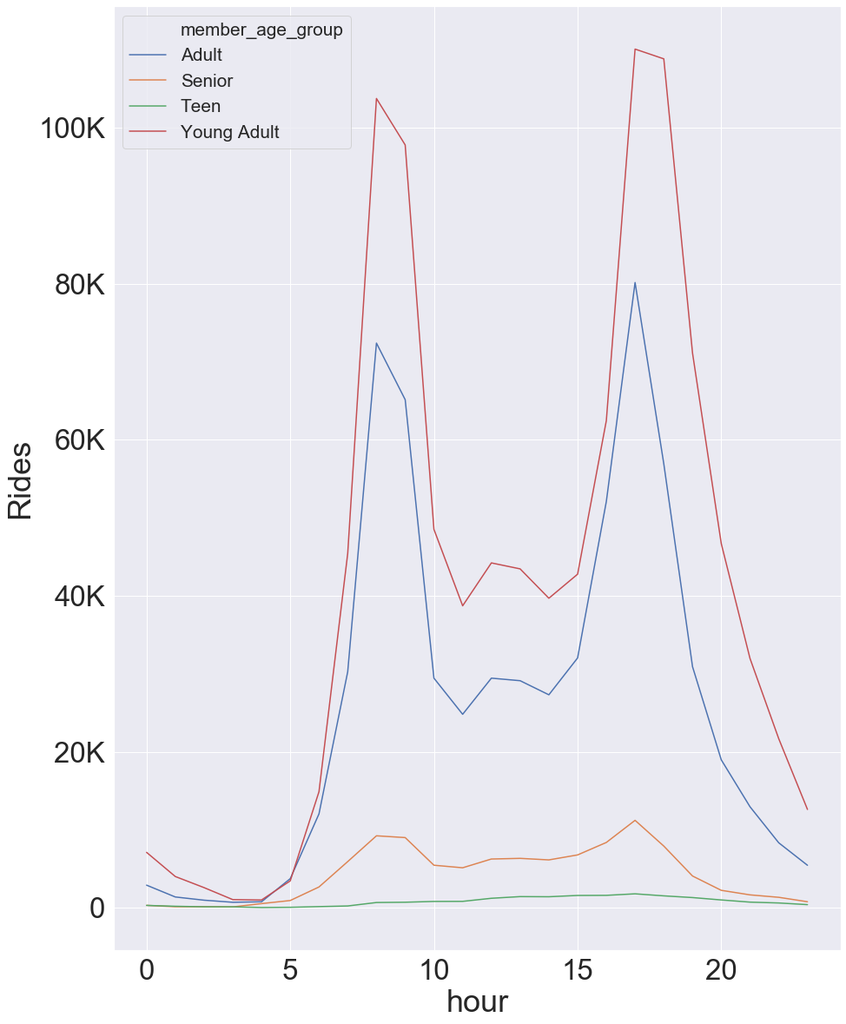

```python
plt.figure(figsize = [15, 20])
dfc_by_age_sample = dfc_by_age.groupby(['member_age_group', 'hour']).bike_id.count().reset_index()
sb.lineplot(data=dfc_by_age_sample, x="hour", y="bike_id", hue="member_age_group")
y_ticks_props = np.arange(0, dfc_by_age.groupby(['member_age_group', 'hour']).bike_id.count().max()+1, 20000);
y_ticks_display = [format_ride_count(numRide) for numRide in y_ticks_props]
plt.yticks(y_ticks_props, y_ticks_display);
plt.ylabel("Rides");
plt.legend(loc=2, fontsize='xx-small');
```

Here, let's do the same but this time using histogram. For a better look, we'll remove the fillings of the bins and only leave the borders so it's easier to trace the trends.

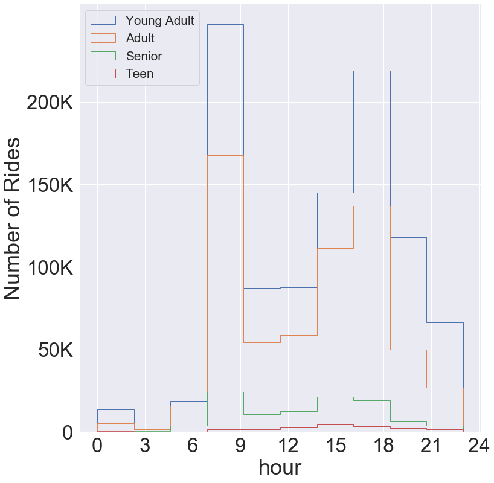

```python
#todo: change the y_tick_props so that it's not hard-coded
g = sb.FacetGrid(data=dfc_by_age, hue="member_age_group", height=12);
g.map(plt.hist, "hour", histtype="step");
plt.legend(fontsize='xx-small', loc=2);
plt.xticks(np.arange(0, 24+1, 3));
plt.ylabel("Number of Rides");
y_ticks_props = np.arange(0, 250000, 50000);
y_ticks_display = [ format_ride_count(numRide) for numRide in y_ticks_props]
plt.yticks(y_ticks_props, y_ticks_display);
```

Wonderful! So through the line plot as well as the pseudo-histogram we can see that almost all the age groups share the same pattern in terms of hourly rides, with two peaks in the morning and late afternoon/early evening. For teens, the pattern is not so obvious but that's also because the sample size is smaller compared to the other groups.

### Q4: In which area does people bike the most?

Notice that this visualization is more like a proof-of-concept experimentation. We wanted to figure out where (here we're primarily curious about the zip) people like to bike. We'll use Google's Geocoding API for computing the zip based on the latitude and longtitude extracted from a small sample of the dataframe (it's not feasible to do all of them because the Geocoding API is costly beyond a certain threshold), then visualize it on a map illustrating the most popular areas where people like to bike. For the sake of simplicity, we'll just use the start location's data for this analysis and visualization, but we can always dive deeper further onwards.

So here we have a problem. I'm not able to find any GeoJson data with zipcode property from the Internet, and the only one I could find is a [link](https://data.sfgov.org/Geographic-Locations-and-Boundaries/Bay-Area-ZIP-Codes/u5j3-svi6) of Bay area's zipcode shape file from the City of San Francisco's [website](https://datasf.org).

However, I'm still going to take advantage of this dataset and do some dirty manual wrangling work to transform this JSON file into a dataset in standard [GeoJson format](https://geojson.org). We'll then use a Python library called Folium to draw the map and visualize the cleaned data on the map.

```python
# todo: add the top 10 most popular stations on the map (as Markers)

# define the center of the map and zoom level, then create the map
SF_COORDINATES = (37.80, -122.30)
map = folium.Map(location=SF_COORDINATES, zoom_start=12)

folium.Choropleth(
        # the cleaned data in GeoJson format
        geo_data="sf_geojson_cleaned.json",
        name='choropleth',
        # trips count grouped by zip
        data=dfc_geo_zip,
        # the foreign key and the column we're interested in
        columns=['zip', 'count'],
        # the Pandas dataframe relates to the GeoJson data's zip property
        key_on='feature.properties.zip',
        fill_color='YlGn',
        fill_opacity=0.6,
        line_opacity=0.2,
        legend_name='Trip Count'
).add_to(map)

# show the populated map
display(map)
```

[interactive chart not shown]

As we can see from the color-coded map, people actually bike over all the Bay Area! Nevertheless, there's clearly more users of BayWheel in the City of San Francisco area rather than in the outskirts (Oakland, Emeryville, Berkeley, Piedmont, Alameda, etc). Within San Francisco, the east side seems more popular, epsecially in the zip areas along the piers, which makes sense as there're lot of companies, businesses and others in those area. For the suburbs, west Oakland has a slightly heavier traffic than the other areas, which are quite residential.

# Main Findings

## Reflection of the Process

- I definitely enjoyed this project more than any other project in the Data Analyst Nanodegree. I'm a pretty visual person and really passionate about my works/findings in a easy-to-understand, aesthetically-pleasing manner. I think the data extraction/cleaning part is relatively straightword as I've already familiared myself with those skills during the previous NanoDegree projects. The visualization part is a bit tricky because it's hard to determine the theme of the visualizations. Different from the two datasets in the lectures, this BayWheel dataset doesn't have many numerical fields (and even for the categorical fields, a lot of them are derived by the original columns), so apparently I can't do a lot of scatter plots or plots of that nature. Instead, I focused on the basic questions: Who? When? Where? (I skipped how and why because they're beyond the scope) of people's biking habits and tried to draw more detailed questions from there. I was able to have a lot of fruitful insights by creating a lot of customized fields and measuing the data against them.
- Another difficult piece of the project I encountered was trying to map the count of trips based on zipcode on a Bay Area map. Believe it or not, it's not as easy as it sounds. I've tried different libraries including GeoPandas and Basemap to no avail, before I turned to Folium, a Python wrapper based on leaflet.js. As I don't have the processed GeoJson data with zip, I created my own with some Python scripts and then managed to (literally) map the results to the map. It was quite an endeavour but rewarding as well.

## Key Insights from Visualization

- From a timing perspective: most people ride on weekdays rather than on the weekend. In terms of specific hours, people mostly ride in the morning and late afternoon/early evening - which might imply that most people ride for commuting, especially for those living in the city. In terms of months, more riders use Baywheel in summer and fall, when the weather is most likely more pleasant than the other seasons.
- From a demographic perspective, the age group with most riders is young adult (aged between 20-35), followed by adults (aged between 35-55). The elder and teens have significant less riders. People aged between 30-40 bike the most, taking a big lead against the runner-up, those aged between 20-30 by almost 200,000 rides. The majority of the riders are regular subscribers rather than customers. Teens, however, ride longer than others with an average trip duration of 17min, where as the young adults seem to have a shorter commute.
- From a geospatial perspective, most riders ride in the City of San Francisco, especially in downtown/financial district and the areas along the piers. For the suburbs, Oakland has a slightly heavier traffic than the other towns, but the coverage of BayWheel is indeed very broad, from Berkeley to Alameda.